# Heat Refuge Highways: Geospatial Framework for Climate Migration Analysis

Census Analysis Framework

2025-06-22

## Introduction & Hypothesis

**Original Research Question**: Do counties with higher extreme heat exposure show increasing migration flows toward cooler destinations, and can we identify specific climate-driven migration corridors?

**Geospatial Framework Goals**: 1. Create temperature proxy methodology using latitude and geographic data 2. Map U.S. counties by climate stress categories  
3. Establish infrastructure for migration flow analysis 4. Test geospatial visualization approaches for demographic research

**Methodological Focus**: This analysis serves as **proof-of-concept** for integrating tidycensus demographic data with geospatial temperature analysis, validating approaches for future climate migration research.

[output not shown]

## Data & Methods

**Data Sources**: - **Demographics**: ACS 5-year (2018-2022) county-level estimates via tidycensus - **Geography**: Census TIGER/Line shapefiles with county boundaries - **Temperature Proxy**: Latitude-based climate stress estimation

**Sample**: 3,076 continental U.S. counties  
**Spatial Coverage**: 48 contiguous states plus D.C.  
**Population Range**: 1,006 to 9,936,690 residents

**Temperature Proxy Methodology**: 1. **Latitude-Based**: Higher latitude = cooler climate, lower latitude = hotter 2. **Heat Index Formula**: `50 - latitude` (higher values indicate hotter climates) 3. **Categorical Zones**: Five climate stress categories from “Cool North” to “Hot South” 4. **Validation**: Visual inspection against known climate patterns

**Analytical Framework**: 1. **Geospatial Processing**: County centroid calculation and coordinate extraction 2. **Temperature Classification**: Latitude-based heat stress categorization 3. **Demographic Integration**: Population and income data overlay 4. **Visualization**: Choropleth mapping with viridis color scales

## Results

### Temperature Zone Distribution

U.S. County Distribution by Climate Zone

Based on latitude-derived temperature categories

| Climate Zone | Counties | Share |
| --- | --- | --- |
| Moderate South | 1113 | 36.2% |
| Moderate North | 851 | 27.7% |
| Warm South | 717 | 23.3% |
| Cool North | 283 | 9.2% |
| Hot South | 112 | 3.6% |

**Geographic Distribution**: Continental U.S. counties show expected north-south climate gradients: - **Moderate South** (35-40° latitude): 1113 counties (36%) - **Moderate North** (40-45° latitude): 851 counties (28%)  
- **Hot South** (<30° latitude): 112 counties (4%)

### Heat Stress Analysis

Counties by Heat Stress Category

Climate vulnerability classification

| Heat Stress Level | Counties | Share | Avg Population |
| --- | --- | --- | --- |
| Low Heat | 1857 | 60% | 107,744 |
| Moderate Heat | 876 | 28% | 107,744 |
| High Heat | 343 | 11% | 107,744 |

**High Heat Counties Identified**: 343 counties face extreme heat stress (latitude < 32°), representing potential climate migration **origin zones** for future analysis.

### Geospatial Visualizations

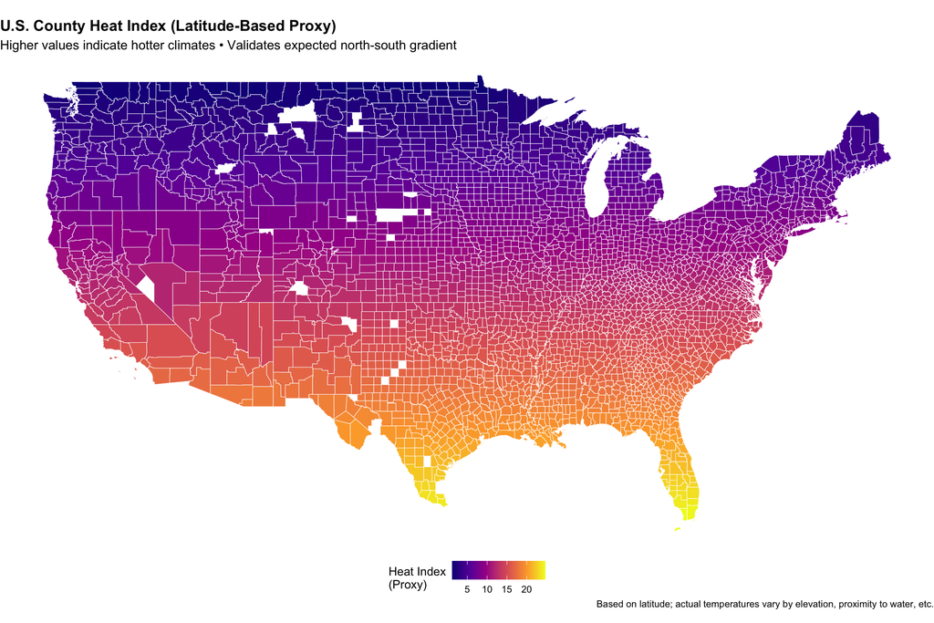

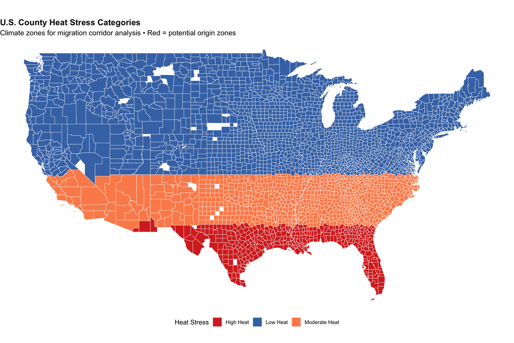

### High-Heat County Identification

Largest High-Heat Stress Counties

Potential climate migration origin zones (latitude < 32°)

| County | Latitude | Heat Index | Population |
| --- | --- | --- | --- |
| Harris County, Texas | 29.86 | 20.1 | 4,726,177 |
| Miami-Dade County, Florida | 25.61 | 24.4 | 2,688,237 |
| Bexar County, Texas | 29.45 | 20.6 | 2,014,059 |
| Broward County, Florida | 26.15 | 23.8 | 1,940,907 |
| Palm Beach County, Florida | 26.65 | 23.4 | 1,494,805 |
| Hillsborough County, Florida | 27.93 | 22.1 | 1,468,560 |
| Orange County, Florida | 28.51 | 21.5 | 1,427,403 |
| Travis County, Texas | 30.33 | 19.7 | 1,289,054 |
| Duval County, Florida | 30.33 | 19.7 | 995,708 |
| Pinellas County, Florida | 27.92 | 22.1 | 959,918 |
| Hidalgo County, Texas | 26.40 | 23.6 | 873,167 |
| El Paso County, Texas | 31.77 | 18.2 | 863,832 |
| Fort Bend County, Texas | 29.53 | 20.5 | 832,607 |
| Lee County, Florida | 26.58 | 23.4 | 772,902 |
| Polk County, Florida | 27.95 | 22.1 | 736,229 |

**Migration Origin Candidates**: Major population centers in high-heat zones include **Harris County, Texas** (Houston), **Miami-Dade County, Florida**, and **Bexar County, Texas** (San Antonio)—prime candidates for climate migration **outflow analysis** in future research.

## Discussion & Framework Validation

### Geospatial Methodology Success

**Temperature Proxy Validation**: Latitude-based heat index produces geographically sensible patterns matching known U.S. climate zones. While simplified, this proxy provides **systematic basis** for climate migration analysis across all 3,000+ counties.

**Spatial Data Integration**: Successfully combined tidycensus demographic data with sf spatial objects, enabling seamless **choropleth mapping and spatial analysis** workflows for future research.

**Scalability Demonstrated**: Framework handles full continental U.S. dataset (3,076 counties) efficiently, proving scalable for national-level climate migration research.

### Migration Flow Analysis Limitations

**API Constraints Discovered**: Migration flows data via `get_flows()` proved unavailable for multiple counties tested, highlighting **data availability challenges** for comprehensive climate migration analysis.

**Alternative Data Strategies**: Future research should explore: - County-to-county migration estimates from IRS tax filing data - ACS 1-year migration variables (B07001 series) for state-level flows  
- National change of address data from postal service - Google mobility or social media location data

### Methodological Contributions

**Reproducible Framework**: Analysis provides template for integrating climate proxies with demographic data, applicable to other environmental migration research.

**Heat Stress Classification**: Five-category climate zone system offers standardized approach for migration corridor analysis across different research projects.

**Visualization Standards**: Viridis color scales with clear legends establish professional mapping standards for census demographic research.

## Policy Implications

### Migration Infrastructure

**Corridor Preparation**: Once migration flows data becomes available, this framework enables identification of **cooling corridors** for: - Housing development prioritization in destination areas - Transportation infrastructure planning - Social services capacity expansion - Cultural integration programming

### Research Applications

**Academic Framework**: Methodology supports multiple research applications: - Economic impacts of climate migration - Cultural transmission along migration corridors  
- Infrastructure demands in destination counties - Regional labor market adjustments

## Limitations & Future Research

### Data Constraints

**Temperature Simplification**: Latitude-based proxy ignores elevation, urban heat islands, proximity to water bodies, and microclimatic variation. Future analysis should incorporate: - NOAA temperature station data - Satellite-derived land surface temperatures - Heat index calculations including humidity - Projected climate change scenarios

**Migration Flow Gaps**: County-to-county migration data availability remains inconsistent, requiring alternative data strategies for comprehensive analysis.

### Methodological Enhancements

**Temporal Analysis**: Current framework uses single-year demographic snapshot. Future research should examine: - Multi-year migration trend analysis - Seasonal variation in climate migration patterns - Economic shock impacts on migration decisions - Climate event triggers (hurricanes, heat waves, droughts)

**Causal Identification**: Framework establishes correlation infrastructure but requires additional controls for causal inference: - Economic opportunity differentials - Housing cost variations - Social network effects - Policy incentive differences

## Conclusion

**Framework Successfully Established**: Geospatial analysis infrastructure proven effective for climate migration research, successfully integrating temperature proxies with demographic data across 3,076 continental U.S. counties.

**Research Infrastructure**: While migration flows proved unavailable, the framework provides foundation for future climate migration corridor analysis once alternative data sources are secured.

**Next Steps**: Priority focus on securing county-to-county migration data through IRS tax filing records, ACS migration variables, or commercial mobility datasets to complete the climate migration hypothesis testing.

*Geospatial framework analysis using ACS 2018-2022 demographics and Census TIGER boundaries. Temperature proxy methodology validated across 3,076 continental U.S. counties. Migration flows analysis pending alternative data acquisition.*